# Premier jour: visualisation(s)

Mardi 25 mai 2021

## Je me présente

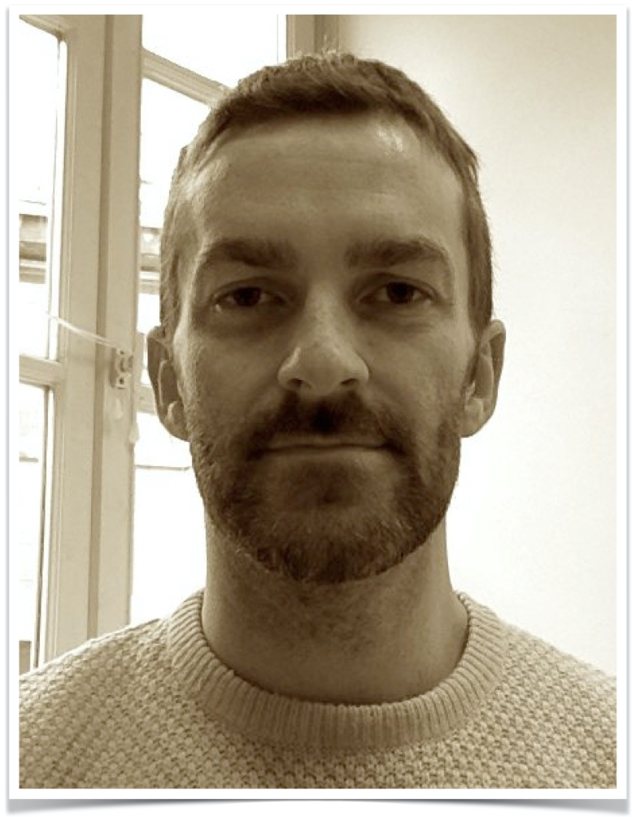

Vincent Guillemot

- Biostatisticien
- Intégration de données
- Machine Learning
- Cours de statistiques et de R

## Quiz de bienvenue

[figure not shown]

Voir le lien et le code sur le chat !

## Au programme

Plutôt le matin

- Quiz de bienvenue
- `dplyr` : pour manipuler des données
- `ggplot2` : pour les graphiques de base
- retour sur les couleurs dans R
- `ggpubr` pour combiner des graphes

Plutôt l’après-midi

- `pheatmap` : pour les cartes de chaleur et la classification hiérarchique
- Diagrammes de Venn et *UpSet* plots
- `gggenes`
- `trackViewer::lolliplot`
- Quiz de fin

## Déroulement du cours

Pour favoriser l’interactivité de ce cours en distanciel, voici ce que je vous propose :

- Deux quiz (Kahoot, cf. programme)
- Des exercices réguliers
- Les étudiant·e·s sont sollicités régulièrement
- Tutoriels interactifs pour s’entraîner “à la maison”

## Des données simples… pour moi

[figure not shown]

Composition de produits alimentaires (https://ciqual.anses.fr/)

## Ressources

- Les [feuilles de triche](https://www.rstudio.com/resources/cheatsheets/) (EN) de
  - [dplyr](https://github.com/rstudio/cheatsheets/raw/master/data-transformation.pdf) (EN)
  - [ggplot2](https://github.com/rstudio/cheatsheets/raw/master/data-visualization-2.1.pdf) (EN)
- La page STDHA sur [les couleurs](http://www.sthda.com/french/wiki/couleurs-dans-r) (FR)
- La page de [ggpubr](https://rpkgs.datanovia.com/ggpubr/) (EN)
- La vignette de [gggenes](https://cran.r-project.org/web/packages/gggenes/vignettes/introduction-to-gggenes.html) (EN)
- La vignette de [trackViewer](https://bioconductor.org/packages/release/bioc/vignettes/trackViewer/inst/doc/trackViewer.html) (EN)
- [R pour les débutants d’Emmanuel Paradis](https://cran.r-project.org/doc/contrib/Paradis-rdebuts_fr.pdf) (FR)

## moRe !

- Livre *R for Data Science* : https://r4ds.had.co.nz/
- Livre *R Cookbook* : https://rc2e.com/
- Livre *Modern Data Science with R* : https://mdsr-book.github.io/mdsr2e/
- Livre *Computational Genomics with R* : https://compgenomr.github.io/book/
- Livre *ggplot2: elegant graphics for data analysis* : https://ggplot2-book.org/index.html
- Site de référence ggplot2 : https://ggplot2.tidyverse.org/reference/
- Extensions ggplot2 : https://exts.ggplot2.tidyverse.org/gallery/
- *A ggplot2 Tutorial for Beautiful Plotting in R* : https://www.cedricscherer.com/2019/08/05/a-ggplot2-tutorial-for-beautiful-plotting-in-r/
- Package R patchwork : https://github.com/thomasp85/patchwork
- Livre *Circular Visualization in R* : https://jokergoo.github.io/circlize_book/book/
- Livre ComplexHeatmap : https://jokergoo.github.io/ComplexHeatmap-reference/book/
- Palettes de couleurs : https://github.com/EmilHvitfeldt/r-color-palettes